# Red wine data exploration by Sonal Garg

# Multivariate Plots Section

## Including Plots

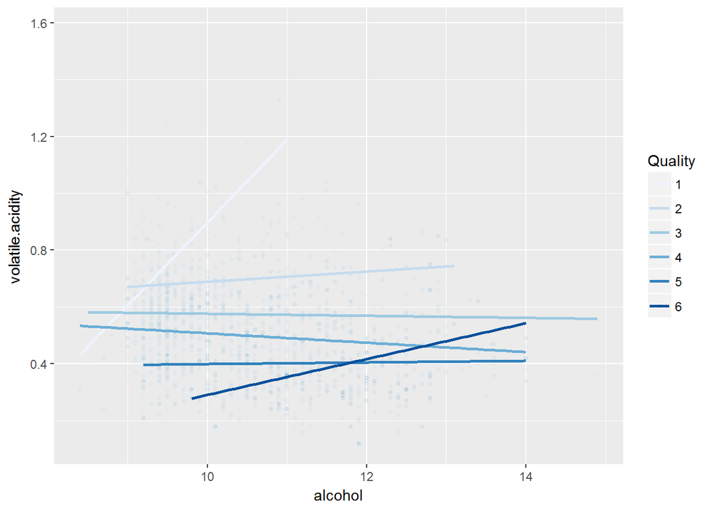

I want to create plots keeping alcohol content constant on the x-axis and varying features on the y-axis .Thus, first creating a plot between alcohol and volatile acidity based on quality. The plot shows that better quality wines have higher alochol content and lesser volatile acidity.

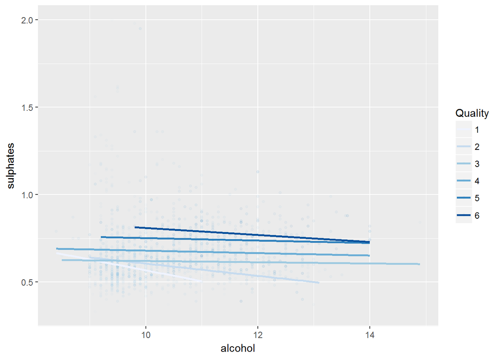

This shows that better quality wines with higher alcoholic content have higher sulphates too.

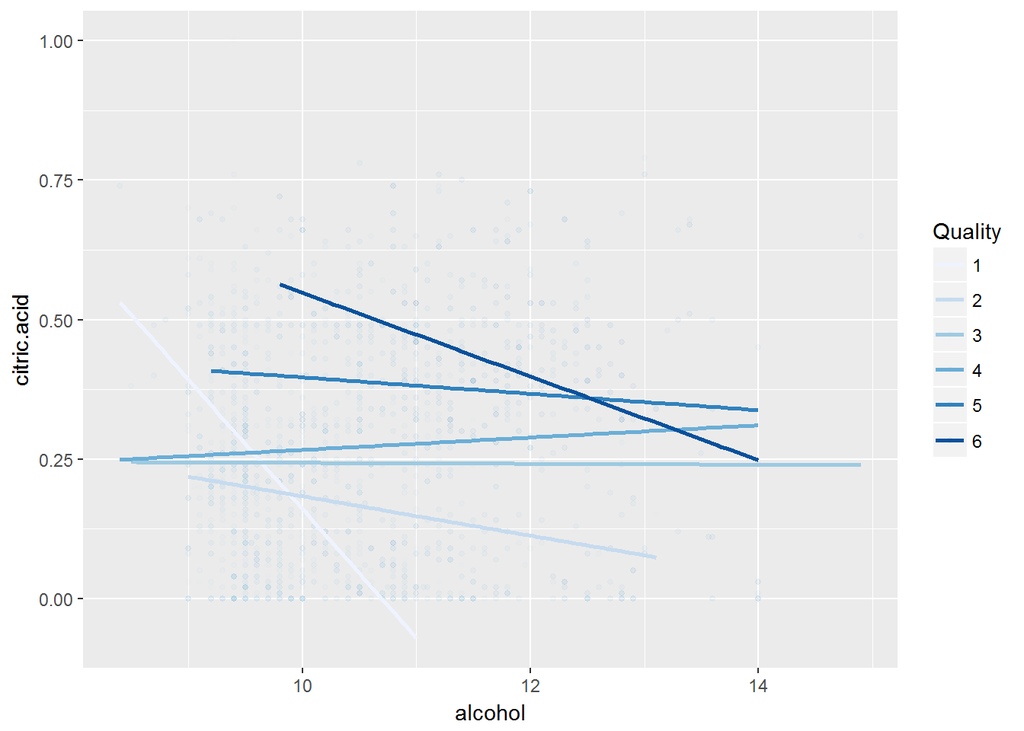

The plot does not seems to indicate any particular trend with citric acid.

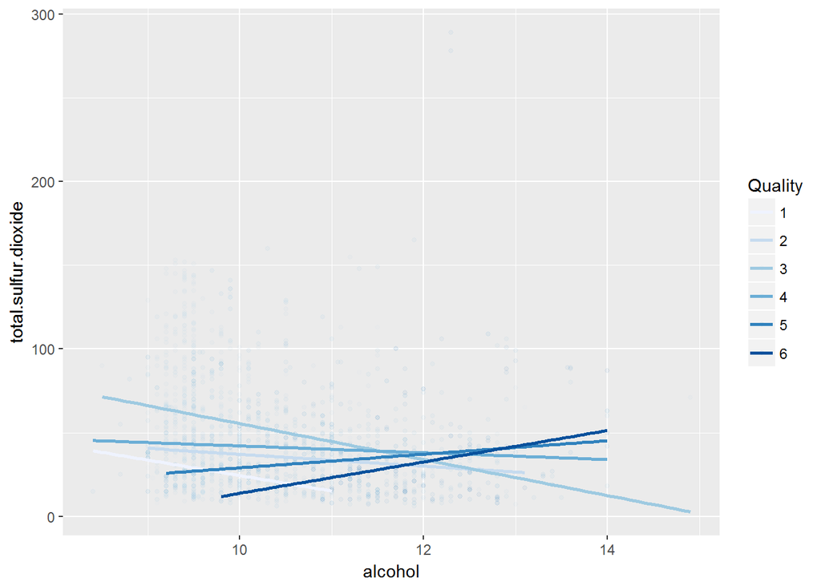

Lesser sulphur dioxide content produces better wines.

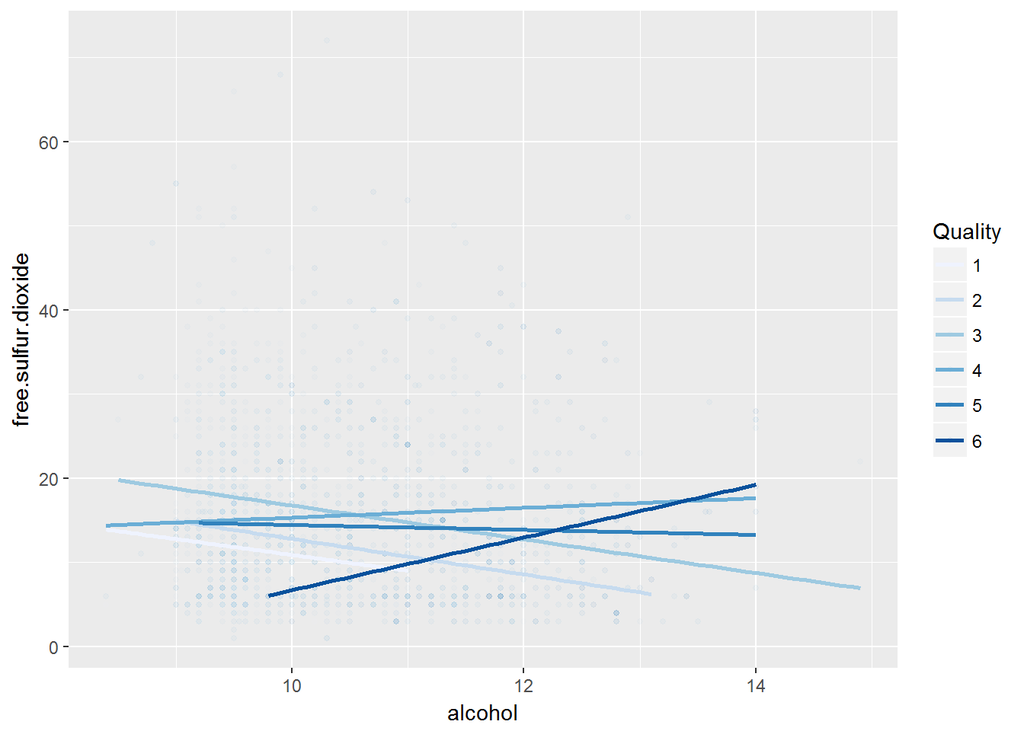

This plot does not indicate a clear relationship between quality and free sulfur dioxide

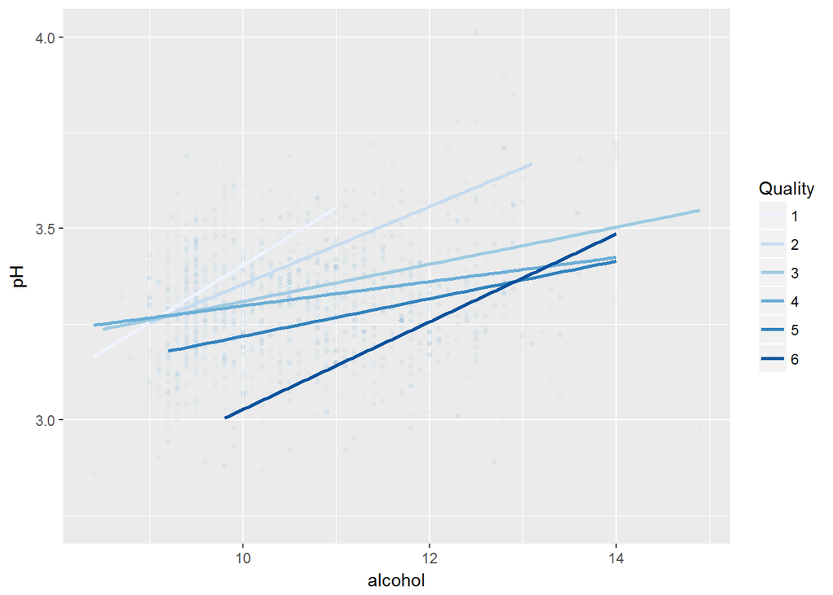

The plot indicates that the average and better quality wines, all have a pH in the range of 3 and 3.7. This was also, previously derived in the analysis. I think, pH thus should not be such an important determining fcator.

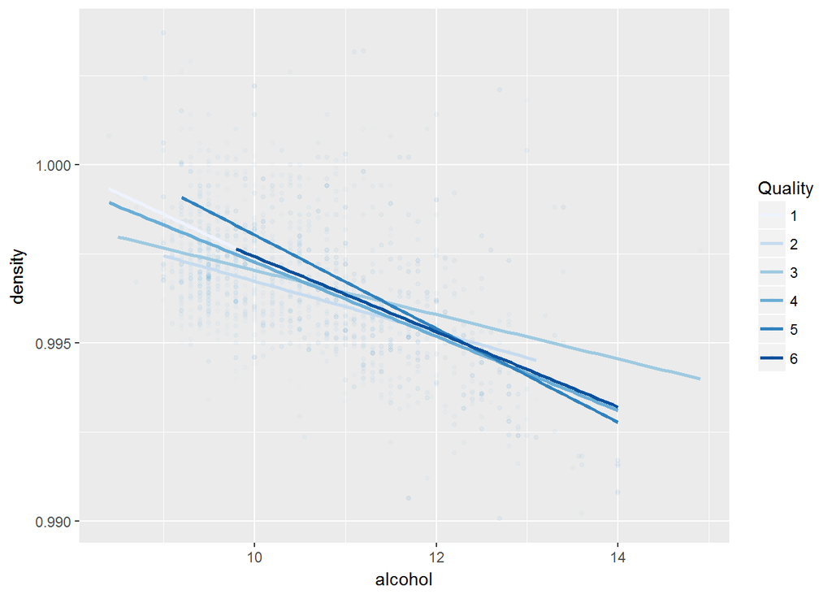

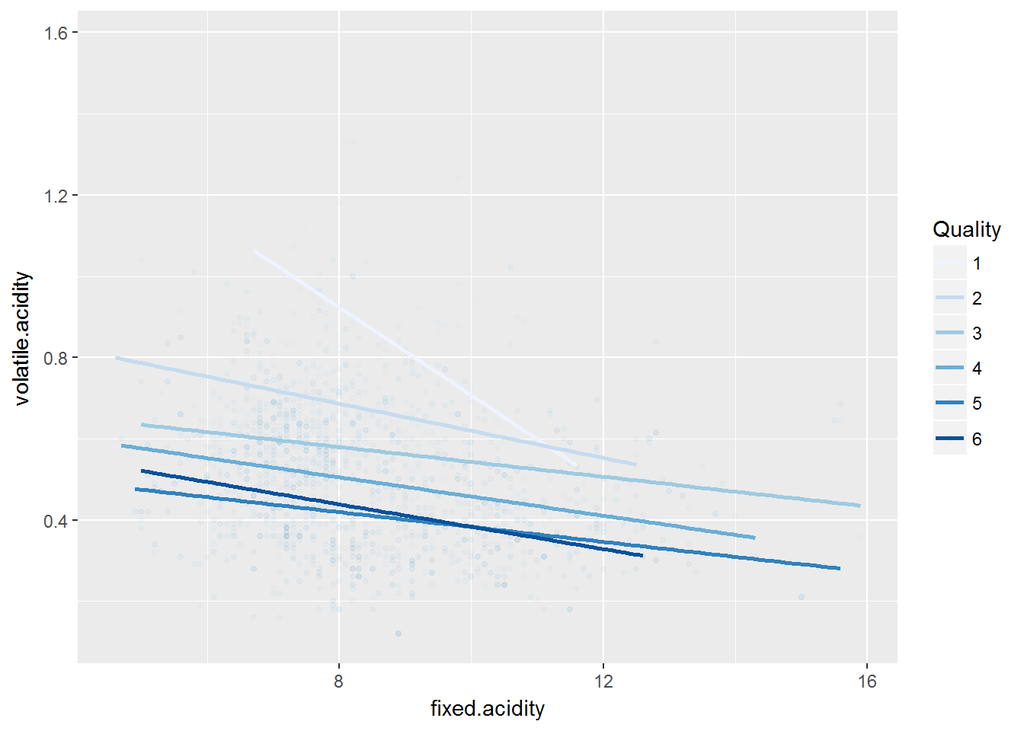

Now I want to check corelation between some of the weaker features. This plot does not seem to conclude anything beneficial.

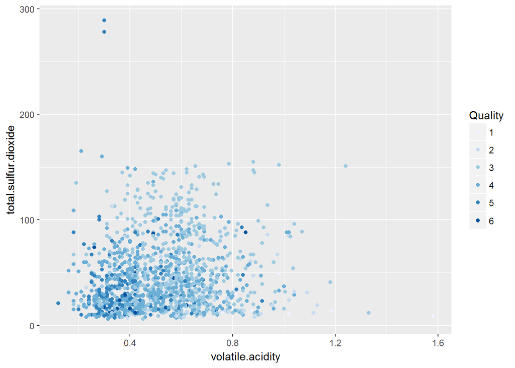

After zooming in the plot, it is clear that lower values of voltaile acidity and total sulphur dioxide leads to better of quality of wines

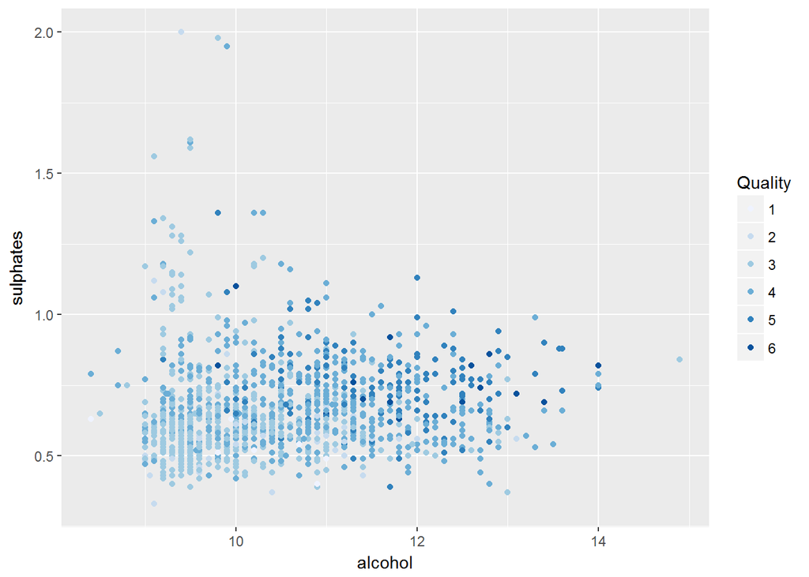

As seen in the plot, better quality of wines lie more in the top right quadrant. Hence, deriving wines with higher alcoholic content and more sulphate content have better quality.

```
##
## Calls:
## m1: lm(formula = I(as.numeric(quality)) ~ I(alcohol), data = pd)
## m2: lm(formula = I(as.numeric(quality)) ~ I(alcohol) + volatile.acidity,
##     data = pd)
## m3: lm(formula = I(as.numeric(quality)) ~ I(alcohol) + volatile.acidity +
##     sulphates, data = pd)
## m4: lm(formula = I(as.numeric(quality)) ~ I(alcohol) + volatile.acidity +
##     sulphates + citric.acid, data = pd)
## m5: lm(formula = I(as.numeric(quality)) ~ I(alcohol) + volatile.acidity +
##     sulphates + citric.acid + pH, data = pd)
##
## ==========================================================================================
##                          m1            m2            m3            m4            m5
## ------------------------------------------------------------------------------------------
##   (Intercept)          -0.125         1.095***      0.611**       0.646**       2.112***
##                        (0.175)       (0.184)       (0.196)       (0.201)       (0.459)
##   I(alcohol)            0.361***      0.314***      0.309***      0.309***      0.327***
##                        (0.017)       (0.016)       (0.016)       (0.016)       (0.017)
##   volatile.acidity                   -1.384***     -1.221***     -1.265***     -1.284***
##                                      (0.095)       (0.097)       (0.113)       (0.112)
##   sulphates                                         0.679***      0.696***      0.673***
##                                                    (0.101)       (0.103)       (0.103)
##   citric.acid                                                    -0.079        -0.297*
##                                                                  (0.104)       (0.120)
##   pH                                                                           -0.475***
##                                                                                (0.134)
## ------------------------------------------------------------------------------------------
##   R-squared             0.227         0.317         0.336         0.336         0.341
##   adj. R-squared        0.226         0.316         0.335         0.334         0.339
##   sigma                 0.710         0.668         0.659         0.659         0.656
##   F                   468.267       370.379       268.912       201.777       165.112
##   p                     0.000         0.000         0.000         0.000         0.000
##   Log-likelihood    -1721.057     -1621.814     -1599.384     -1599.093     -1592.801
##   Deviance            805.870       711.796       692.105       691.852       686.429
##   AIC                3448.114      3251.628      3208.768      3210.186      3199.602
##   BIC                3464.245      3273.136      3235.654      3242.448      3237.242
##   N                  1599          1599          1599          1599          1599
## ==========================================================================================
```

# Multivariate Analysis

### Talk about some of the relationships you observed in this part of the investigation. Were there features that strengthened each other in terms of looking at your feature(s) of interest?

Below are some of my observations:

- Two positively correlated feature alcohol and sulphates and two negatively correlated features total sulfur dioxide and volatile acidity seems to be the driving factors of quality.
- According to me, these three features are the most important determining factors of quality here.
- Also, lower pH values produce better quality wines.

### Were there any interesting or surprising interactions between features?

Citric acid and density initially seemed to me a small but important determination factor. However, eventually they appear to have a much smaller impact in determination of quality as opposed to other features.

### OPTIONAL: Did you create any models with your dataset? Discuss the strengths and limitations of your model.

Below are the observations of the linear model:

- We find that the features can account for 34.1 % of the quality of wines.
- Also, I had concluded that alcohol would be the most important determining factor of quality. However, the linear model suggests that alcohol content accounts for 22.7 % of quality only.
- None of the features have a very high R squared value. This goes to show, that correlation between any feature is not very high with quality

# Final Plots and Summary

### Plot One

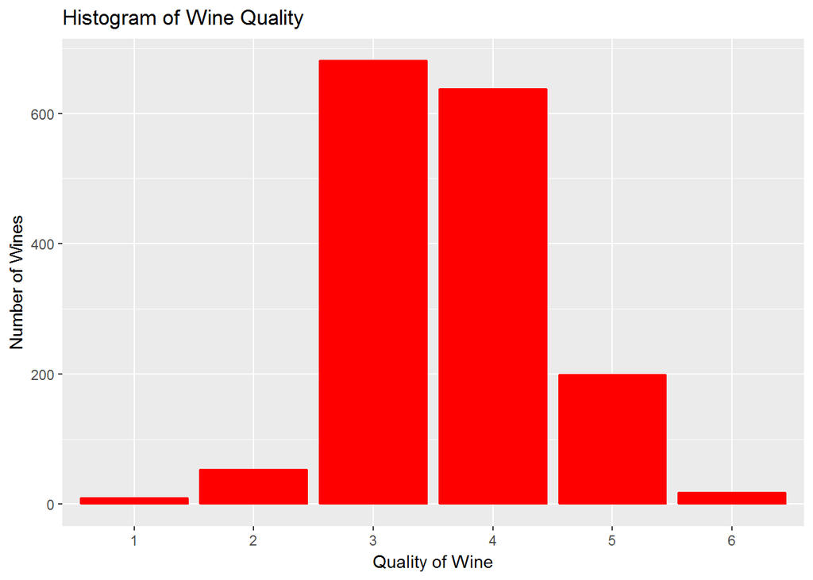

### Description One

This plot provided the first analysis result that majority of wines are of medium quality in our data set. Later, it is found out that this limited variety of dataset also restricts our final analysis results.

Here, average quality wines account for 82.4% of all the wines in our dataset.I believe,a more diverse dataset would help us understand the impact of each feature in more detail.

### Plot Two

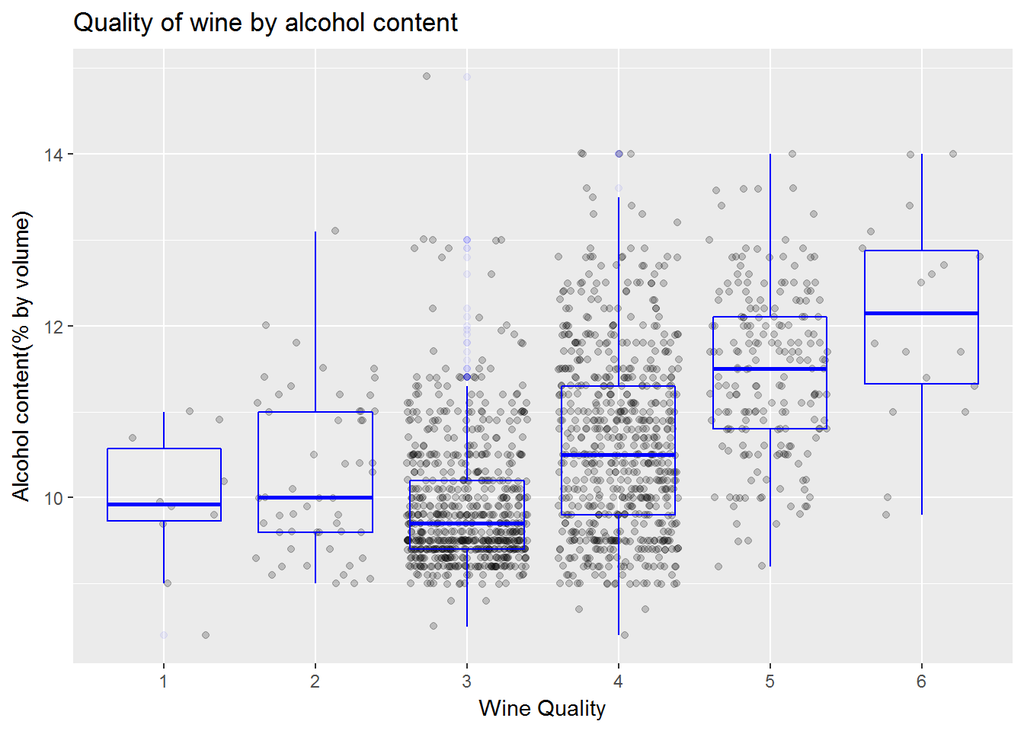

### Description Two

Since, alcohol has the strongest correlation with quality, this is one of the more important plot. The higher the alcohol content, the better the wine quality.

However, from our linear model test, we saw from the R Squared value that alcohol only accounts for 22% in the variance of the wine quality. So alcohol is not the only determining factor of quality.

### Plot Three

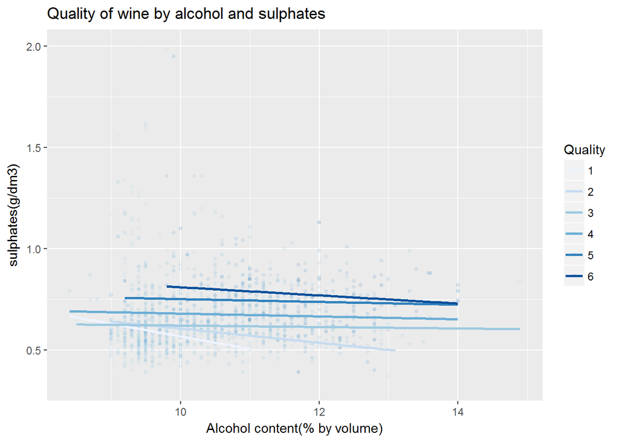

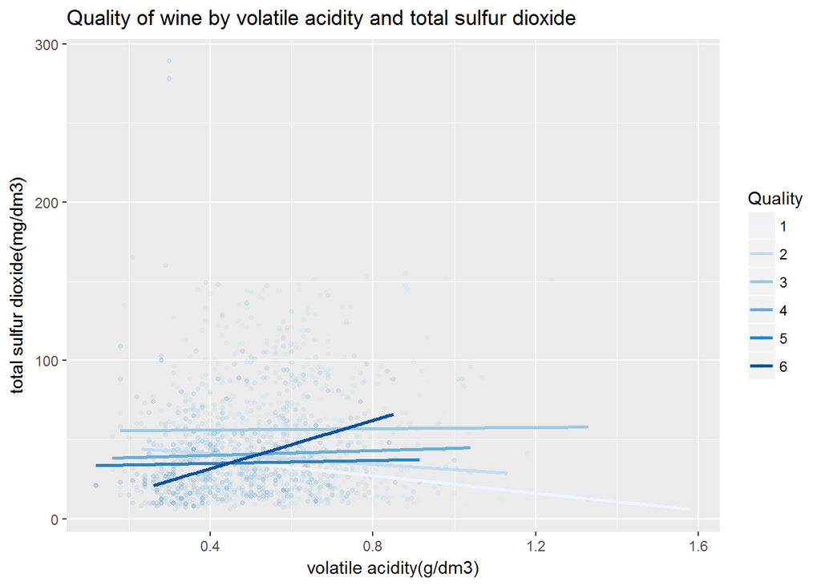

### Description Three

In this final plot,we are plotting the two positive and the two negative correlations we found with quality.

# Reflection

I started with the individual analysis of features. The first observation related to the data set was that we are provided with only average quality of wines. This shows that the data set is not very diverse in terms of the samples observed. During univariate analysis, each feature was observed for its distribution and outliers . Then, I proceeded with the bivariate analysis where, I plotted each feature with quality. These plots streamlined the analysis, pointing that some of the factors were more prominent in determination of quality than others. The factors observed here were:

- Alcohol
- Volatile acidity
- Total sulphur dioxide
- Sulphates
- pH
- Citric Acid
- Density

Now, with the current analysis, it was formed that alcohol seemed to be the most important determining factor of quality. Moving, further with multivariate analysis, I plotted alcohol with other important factors based on wine quality.

These plots helped deduced that pH, density and citric acid are not very important factors and the driving factors of quality are :

- alcohol
- sulphates
- volatile acidity
- total sulphur dioxide

Finally, I plotted a linear model. The results were not very encouraging as I deduced that the features in the linear model can account for only 34.1 % of the quality of wines.

So, overall my conclusion is that, we should include more diverse sample sets with different quality of wines ranging from very poor to very good .This will help in improving the accuracy of analysis.

> As per current data set, I feel, alcohol, sulphates, total sulphur dioxide and volatile acidity are primarily the driving factors of quality.